# Repair Cafes Worldwide Analysis

## TidyTuesday Section

Explore the week’s [TidyTuesday](https://github.com/rfordatascience/tidytuesday) challenge. Develop a research question, then answer it through a short data story with [effective visualization(s)](https://github.com/rfordatascience/tidytuesday). Provide sufficient background for readers to grasp your narrative.

Repair Cafes are volunteer-run community events where people bring broken household items and try to fix them with help from experienced repairers. The dataset for this week comes from Repair Monitor and contains records of repair attempts from Repair Cafes worldwide. Since these events focus on reducing waste and extending product life, the data can help show which types of items are most likely to be repaired successfully.

## Dataset Import From TidyTuesday

```r
library(tidytuesdayR)
library(dplyr)
library(ggplot2)
library(readr)
library(forcats)
library(scales)
tuesdata <- tidytuesdayR::tt_load(2026, week = 14)
```

```
---- Compiling #TidyTuesday Information for 2026-04-07 ----
```

```
--- There are 2 files available ---


── Downloading files ───────────────────────────────────────────────────────────

  1 of 2: "repairs.csv"
  2 of 2: "repairs_text.csv"
```

```r
repairs <- tuesdata$repairs
repairs_text <- tuesdata$repairs_text
```

## Research Question

Which product categories are repaired most successfully, and among commonly repaired categories, which ones have the highest repair success rates?

## Data Exploration

```r
glimpse(repairs)
```

```
Rows: 178,749
Columns: 11
$ repair_id                    <chr> "0550_2026_0214_006", "0550_2026_0214_005…
$ repair_date                  <date> 2026-02-14, 2026-02-14, 2026-03-07, 2025…
$ repair_cafe_number           <dbl> 550, 550, 250, 882, 250, 882, 250, 250, 2…
$ repair_cafe_name             <chr> "Louth", "Louth", "Madrid Medialab Matade…
$ country                      <chr> "GB", "GB", "ES", "GB", "ES", "GB", "ES",…
$ kind_of_product              <chr> "Vacuum cleaner", "Accordion", "Televisio…
$ category                     <chr> "Household appliances electric", "Display…
$ brand                        <chr> "Henry", "Microvox", "LG", "Miele", "Unkn…
$ estimated_year_of_production <dbl> 2005, 1999, 2017, 2007, NA, NA, NA, 2010,…
$ repaired                     <chr> "no", "no", "no", "half", "yes", "half", …
$ repairability                <dbl> 3, 6, 7, NA, 7, NA, NA, 7, NA, NA, 9, 7, …
```

```r
repairs %>%
  summarise(
    n_repairs = n(),
    n_categories = n_distinct(category),
    n_countries = n_distinct(country),
    min_repairability = min(repairability, na.rm = TRUE),
    median_repairability = median(repairability, na.rm = TRUE),
    mean_repairability = mean(repairability, na.rm = TRUE),
    max_repairability = max(repairability, na.rm = TRUE)
  )
```

```
# A tibble: 1 × 7
  n_repairs n_categories n_countries min_repairability median_repairability
      <int>        <int>       <int>             <dbl>                <dbl>
1    178749           15          25                 0                    7
# ℹ 2 more variables: mean_repairability <dbl>, max_repairability <dbl>
```

The dataset contains **178,749 repair records** across **15 product categories** and **25 countries**. This is a fairly large dataset, so the overall patterns should be meaningful rather than driven by only a few observations. The median repairability score is **7**, which suggests that many items brought to Repair Cafes are at least moderately repairable. The minimum repairability score is **0**, so some products are viewed as extremely difficult or effectively impossible to repair.

```r
repairs %>%
  count(repaired, sort = TRUE)
```

```
# A tibble: 5 × 2
  repaired      n
  <chr>     <int>
1 yes      112775
2 no        43112
3 half      22859
4 <NA>          2
5 ja            1
```

The repair outcome counts show that **“yes”** is by far the most common result, with **112,775** successful repairs. This is much higher than **43,112** cases marked **“no”** and **22,859** marked **“half”**. The bar chart makes this pattern very clear: successful repairs dominate the dataset, while partial and unsuccessful repairs occur much less often. There are also a few unusual values, such as **“ja”** and **NA**, which likely reflect data entry inconsistencies and should be treated carefully in later cleaning.

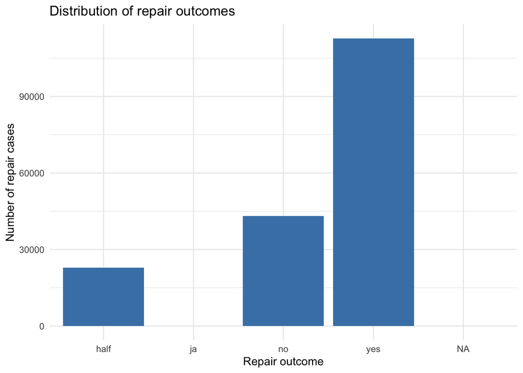

```r
ggplot(repairs, aes(x = repaired)) +
  geom_bar(fill = "steelblue") +
  labs(
    title = "Distribution of repair outcomes",
    x = "Repair outcome",
    y = "Number of repair cases"
  ) +
  theme_minimal()
```

```
Warning: Removed 53885 rows containing non-finite outside the scale range
(`stat_bin()`).
```

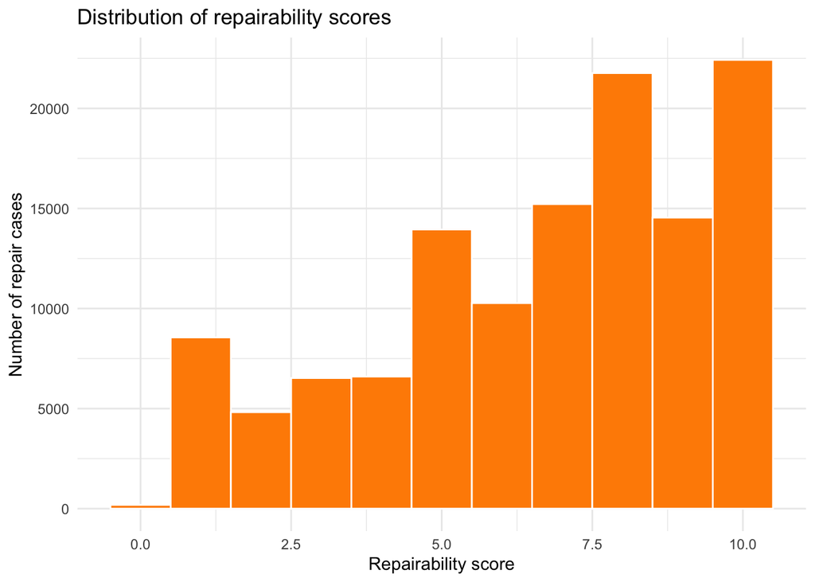

```r
ggplot(repairs, aes(x = repairability)) +
  geom_histogram(binwidth = 1, fill = "darkorange", color = "white") +
  labs(
    title = "Distribution of repairability scores",
    x = "Repairability score",
    y = "Number of repair cases"
  ) +
  theme_minimal()
```

The histogram shows that repairability scores are concentrated more heavily at the higher end of the scale, especially around **7 to 10**. This suggests that many of the products appearing in the dataset are considered fairly repairable. Lower scores are present, but they are less common. The warning above the plot indicates that many rows were removed because of missing repairability values, so this graph reflects only the cases where a repairability score was actually recorded.

## Data Cleaning

```r
repair_summary <- repairs %>%
  filter(!is.na(category), !is.na(repaired)) %>%
  mutate(
    repair_success = repaired == "yes"
  ) %>%
  group_by(category) %>%
  summarise(
    total_repairs = n(),
    repaired_n = sum(repair_success, na.rm = TRUE),
    repair_rate = mean(repair_success, na.rm = TRUE)
  ) %>%
  ungroup()

top_categories <- repair_summary %>%
  filter(total_repairs >= 100) %>%
  arrange(desc(total_repairs)) %>%
  slice_head(n = 10)

top_categories
```

```
# A tibble: 10 × 4
   category                          total_repairs repaired_n repair_rate
   <chr>                                     <int>      <int>       <dbl>
 1 Household appliances electric             70983      39244       0.553
 2 Textile                                   24412      22520       0.922
 3 Display and sound equipment               20414       9352       0.458
 4 Other                                     10434       7026       0.673
 5 Tools electric                            10340       5586       0.540
 6 Computer equipment / phones                9488       4401       0.464
 7 Clocks / alarm clocks                      7016       4325       0.616
 8 Bicycles                                   6252       5105       0.817
 9 Household appliances non-electric          5593       4550       0.814
10 Tools non-electric                         4178       3759       0.900
```

In this analysis, I focus on categories with at least 100 repair attempts so that the comparison is based on categories with substantial data. This avoids drawing conclusions from categories with very small counts.

## Visualization

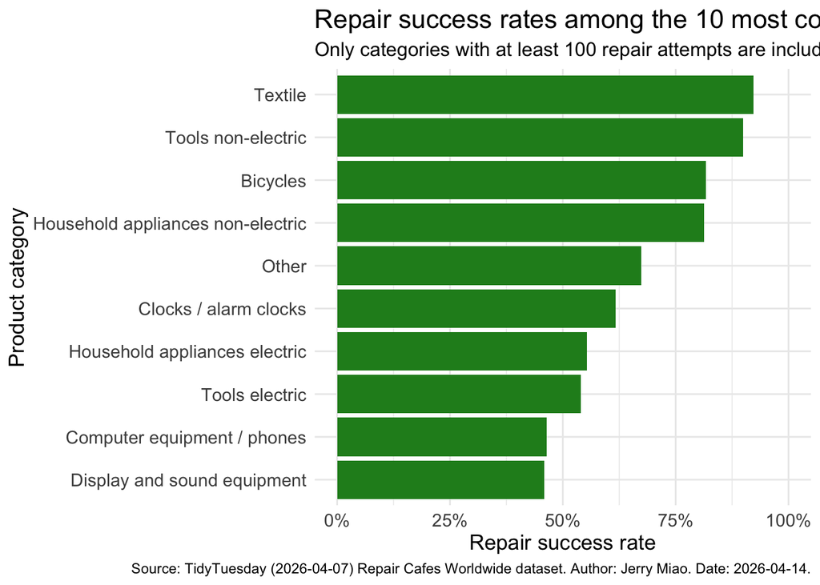

```r
ggplot(
  top_categories,
  aes(
    x = repair_rate,
    y = fct_reorder(category, repair_rate)
  )
) +
  geom_col(fill = "forestgreen") +
  scale_x_continuous(
    labels = percent_format(accuracy = 1),
    limits = c(0, 1)
  ) +
  labs(
    title = "Repair success rates among the 10 most common product categories",
    subtitle = "Only categories with at least 100 repair attempts are included",
    x = "Repair success rate",
    y = "Product category",
    caption = "Source: TidyTuesday (2026-04-07) Repair Cafes Worldwide dataset. Author: Jerry Miao. Date: 2026-04-14."
  ) +
  theme_minimal() +
  theme(
    plot.title = element_text(size = 16),
    plot.subtitle = element_text(size = 12),
    axis.title.x = element_text(size = 13),
    axis.title.y = element_text(size = 13),
    axis.text.x = element_text(size = 11),
    axis.text.y = element_text(size = 11)
  )
```